# Errorbar Plots using Mirrored Axis Distortion of Fold Change (MAD-FC) Transform

# 1 Introduction

This vignette illustrates how to use a MAD-FC transform to visualize fold change measurements in a plot with interval estimates of uncertainty. We will compare visualizing the same data with a linear, log2, and MAD-FC transform. Each of these transforms exhibit different characteristics and emphasizes different aspects of the data, so much so that at first glance it appears that each of these plots are of different datasets.

*Reference for MAD-FC*

B. A. Corliss, Y. Wang, F. P. Driscoll, H. Shakeri, P. E. Bourne, MAD-FC: A Fold Change Visualization with Readability, Proportionality, and Symmetry (2023), doi:10.48550/arXiv.2303.10829.

# 2 Dataset and Code Sources

**Dataset Availability:** This vignette uses a datapoints that were visually extracted from Figure 6a from the following publication:  
O’Shea J., Cremona M., Morgan C., Milewska M., Holmes F., Espina V., Liotta L., O’Shaughnessy J., Toomey S., Madden S. F., Carr A., Elster N., Hennessy B. T., et al A preclinical evaluation of the MEK inhibitor refametinib in HER2-positive breast cancer cell lines including those with acquired resistance to trastuzumab or lapatinib. Oncotarget. 2017; 8: 85120-85135. doi.org/10.18632/oncotarget.19461.

Datapoints were visualy extracted from [WebPLotDigitizer](https://automeris.io/WebPlotDigitizer/).

# 3 Package Dependencies

**Primary Packages:** *tidyverse*

The MAD-FC source file is also required (mirrored_axis_distortion.R)

```r
# Install required Base Packages
base_packages <- c("cowplot", "tidyverse")
install.packages(setdiff(base_packages, rownames(installed.packages())))

# Load base packages
lapply(base_packages, library, character.only = TRUE)
source(paste0(dirname(getwd()), "/R/mirrored_axis_distortion.R"))
```

# 4 Data Analysis Steps

We processing the data with the following steps:

```r
# Load data from csv file
df0 <- read.csv(paste0(getwd(), "/data/protein_expression_John O’Shea.csv"))
df <- pivot_longer(df0,cols = -c("X", "label"),
                   names_to = "color_pt",values_to = "fc") %>%
  separate(color_pt, c("color", "pt"), '_') %>%
  pivot_wider(names_from = pt, values_from = fc)

df$log2_hi <- log2(df$hi)
df$log2_mid <- log2(df$mid)
df$log2_lo <- log2(df$lo)

df$mfc_hi <- contract1(fc_to_mfc(df$hi))
df$mfc_mid <- contract1(fc_to_mfc(df$mid))
df$mfc_lo <- contract1(fc_to_mfc(df$lo))
```

# 5 Visualization

We now will visualize the same dataset with an errorbar plot where fold changes are linear, log2, and MAD-FC transformed. Each type of transform has unique characteristics for how it displays the fold change values.

## 5.1 Linear Errorbar Plot

We first produce an errorbar plot where fold changes are mapped to a linear scale (raw fold change units, y-axis). Notice that with this plot, negative fold changes are compressed between [0,1) and positive fold changes are between (1,inf). This limits the linear plot’s usefulness in comparing the datapoints and intervals between positive and negative fold change values.

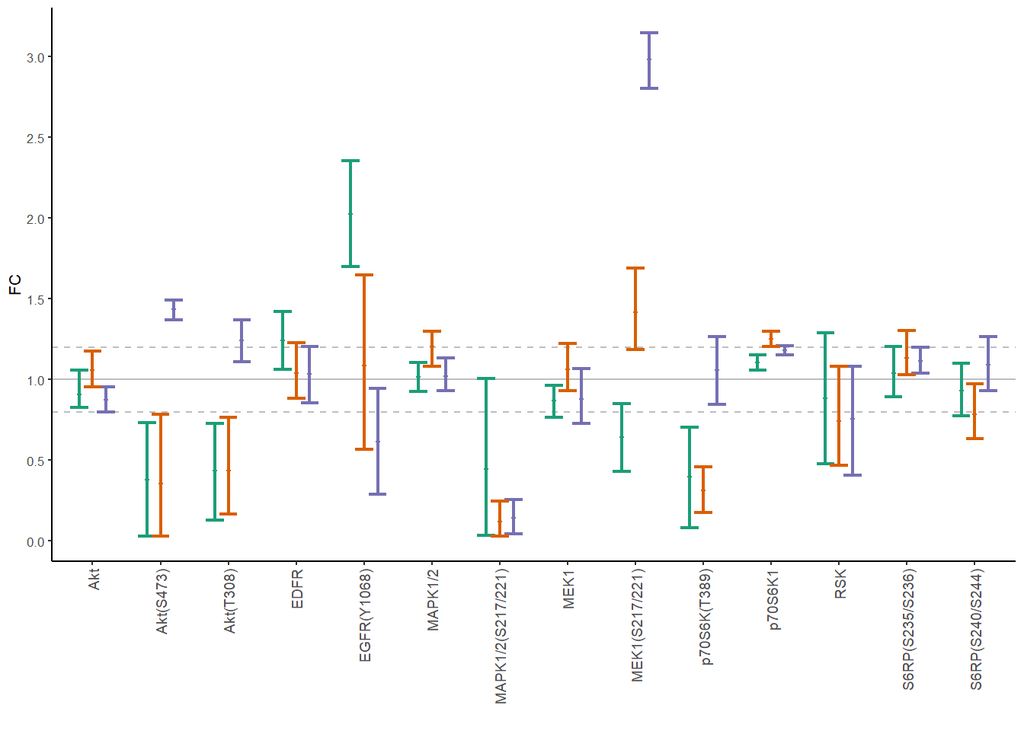

```r
# Fold Change Linear Plot
g1 <- ggplot(data = df,aes(x=label, y = mid, color = color)) +
  geom_hline(yintercept = 1, color = "grey") +
  geom_hline(yintercept = c(1.2, 0.8), color = "grey", linetype = "dashed") +
  geom_errorbar(aes(ymax = hi, ymin = lo), linewidth = .8, width = .8,
                position=position_dodge(width = 0.6), alpha = 1) +
  geom_point(size = .8,position=position_dodge(width = 0.6),alpha = 1) +
  theme_classic(base_size = 8) +
  theme(axis.text.x = element_text(angle = 90, vjust = 0.5, hjust=1, size=7),
          legend.position = "none", legend.justification = c("right", "top"),
          legend.box.just = "right", legend.margin = margin(6, 6, 6, 6)
        ) +
  scale_color_manual(name = "Treatment", labels = c("MEKi", "PI3Ki", "MEKI:PI3Ki"),
                     values = c("#1b9e77", "#d95f02", "#7570b3")) +
  scale_y_continuous(breaks=seq(0,3,.5)) +
  xlab("") + ylab("FC")
g1
```

## 5.2 Log Errorbar plot

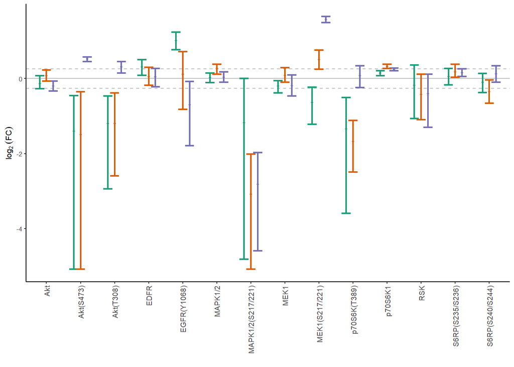

```r
# FOld Change Log2 Plot
g2 <- ggplot(data = df,aes(x=label, y = log2_mid, color = color)) +
  geom_hline(yintercept = 0, color = "grey") +
  geom_hline(yintercept = c(-.26, 0.26), color = "grey", linetype = "dashed") +
  geom_errorbar(aes(ymax = log2_hi, ymin = log2_lo), linewidth = .8, width = .8,
                position=position_dodge(width = 0.6), alpha = 1) +
  geom_point(size = .8,position=position_dodge(width = 0.6),alpha = 1) +
  theme_classic(base_size = 8) +
  theme(axis.text.x = element_text(angle = 90, vjust = 0.5, hjust=1, size=7),
        legend.position = "none") +
  scale_color_manual(name = "Treatment", labels = c("MEKi", "PI3Ki", "MEKI:PI3Ki"),
                     values = c("#1b9e77", "#d95f02", "#7570b3")) +
  scale_shape_manual(name = "Treatment", labels = c("MEKi", "PI3Ki", "MEKI:PI3Ki"),
                     values = c(18, 15, 17)) +
  xlab("") + ylab(expression(log[2]~(FC)))
g2
```

## 5.3 MAD Errorbar Plot

Finally we produce a Errorbar plot of the same data where fold changes are mapped to a MAD-FC scale (linear fold change units with negative fold change scale distorted to match the scale of positive fold changes). MAD plots are symmetrical and linear by design, making it easier to compare datapoints and intervals regardless of fold change direction. The linear mapping also makes it easy to recover the original datapoint position from the plot.

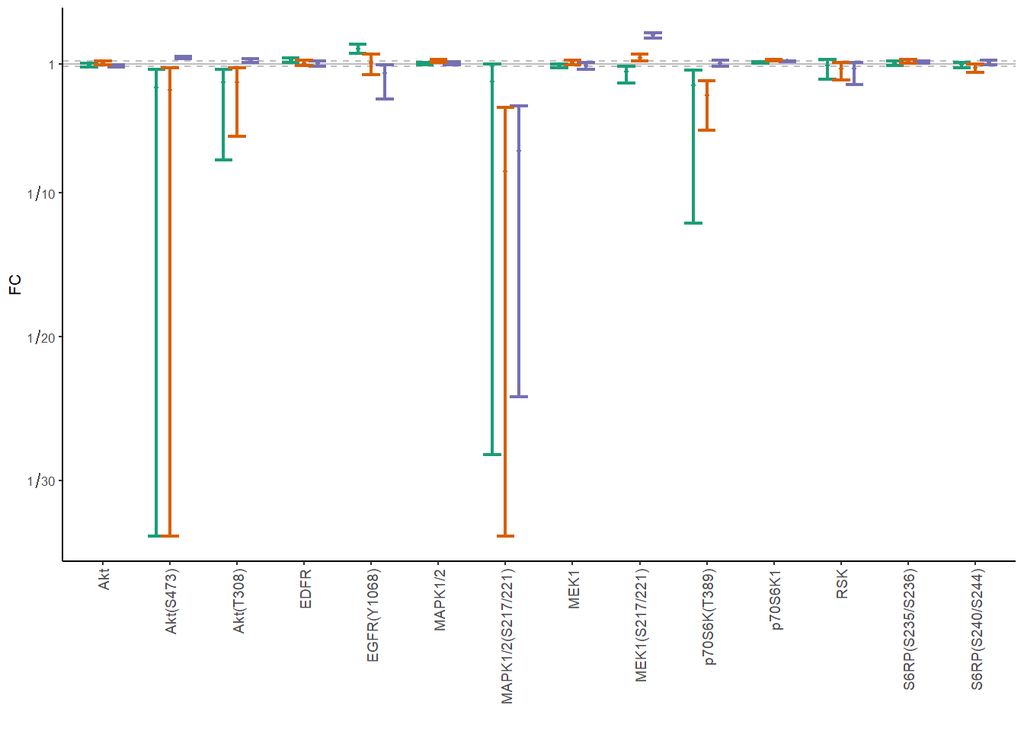

```r
# MAD Fold Change Plot
g3 <- ggplot(data = df,aes(x=label, y = mfc_mid, color = color)) +
  geom_hline(yintercept = 0, color = "grey") +
  geom_hline(yintercept = c(.2, -0.2), color = "grey", linetype = "dashed") +
  geom_errorbar(aes(ymax = mfc_hi, ymin = mfc_lo), linewidth = .8, width = .8,
                position=position_dodge(width = 0.6), alpha = 1) +
  geom_point(size = .8,position=position_dodge(width = 0.6),alpha = 1) +
  theme_classic(base_size = 8) +
  theme(axis.text.x = element_text(angle = 90, vjust = 0.5, hjust=1, size=7),
        legend.position = "none", legend.justification = c("right", "top"),
        legend.box.just = "right", legend.margin = margin(6, 6, 6, 6) ) +
  scale_color_manual(name = "Treatment", labels = c("MEKi", "PI3Ki", "MEKI:PI3Ki"),
                     values = c("#1b9e77", "#d95f02", "#7570b3")) +
  scale_shape_manual(name = "Treatment", labels = c("MEKi", "PI3Ki", "MEKI:PI3Ki"),
                     values = c(18, 15, 17)) +
  xlab("") + ylab("FC")
g3 <- gg_revaxis_mfc(g3,'y', num_format = "fraction")
g3
```

Bruce Corliss, 10/16/2023